# VOC DH-Stopping Project

Alexia Hernandez<sup>1</sup>

Robert J. Podesva<sup>1</sup>

Anthony R. Velasquez<sup>1</sup>

Marie Tano<sup>1</sup>

Brandon Papineau<sup>1</sup>

<sup>1</sup>*Stanford University

26 April, 2023

# Analysis

## Linguistic Factors

### Frequency

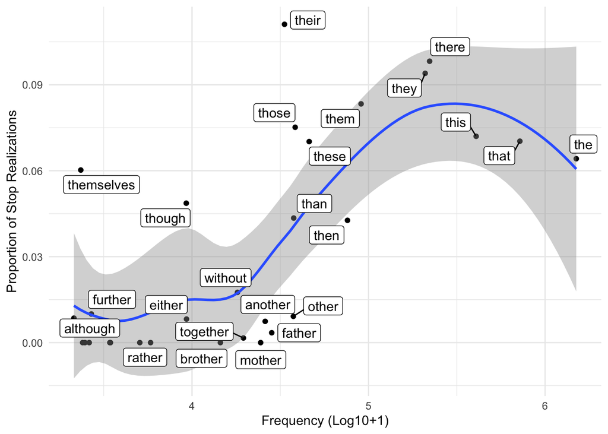

### Frequency and Stress

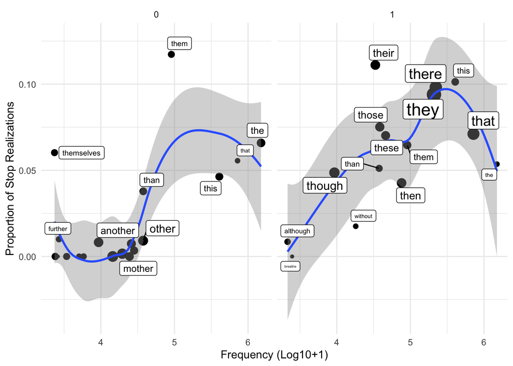

### Lexical Type & Stress

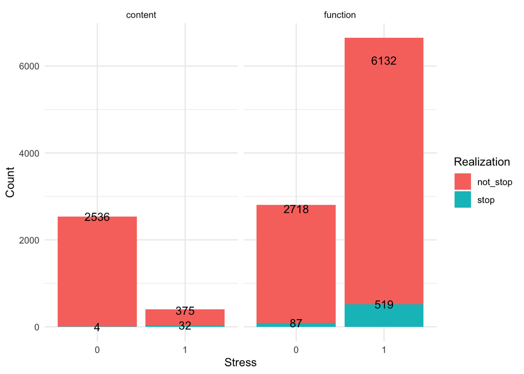

### Preceding Environment

- Based on this plot below, we might want to consider D separately

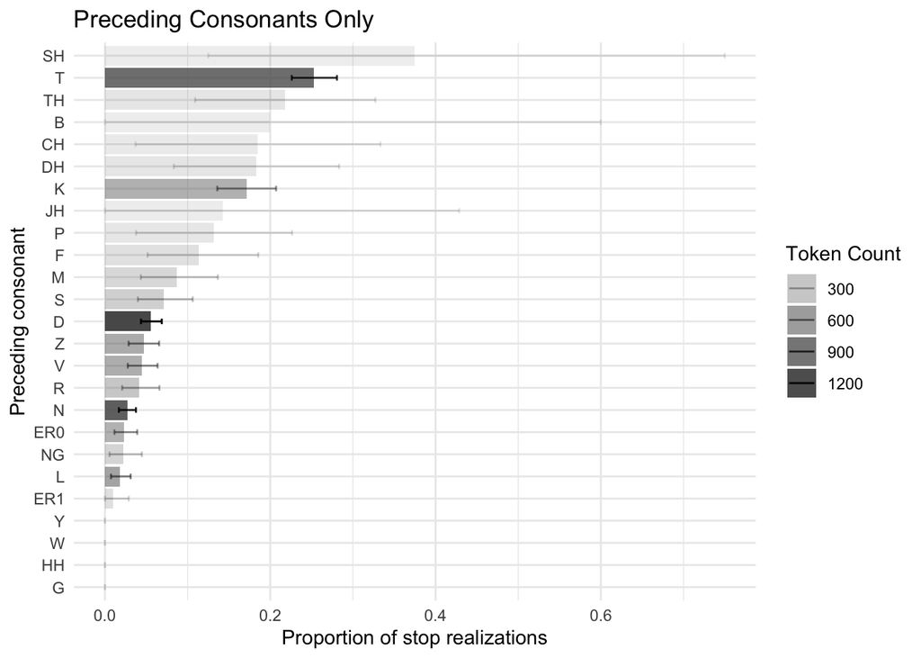

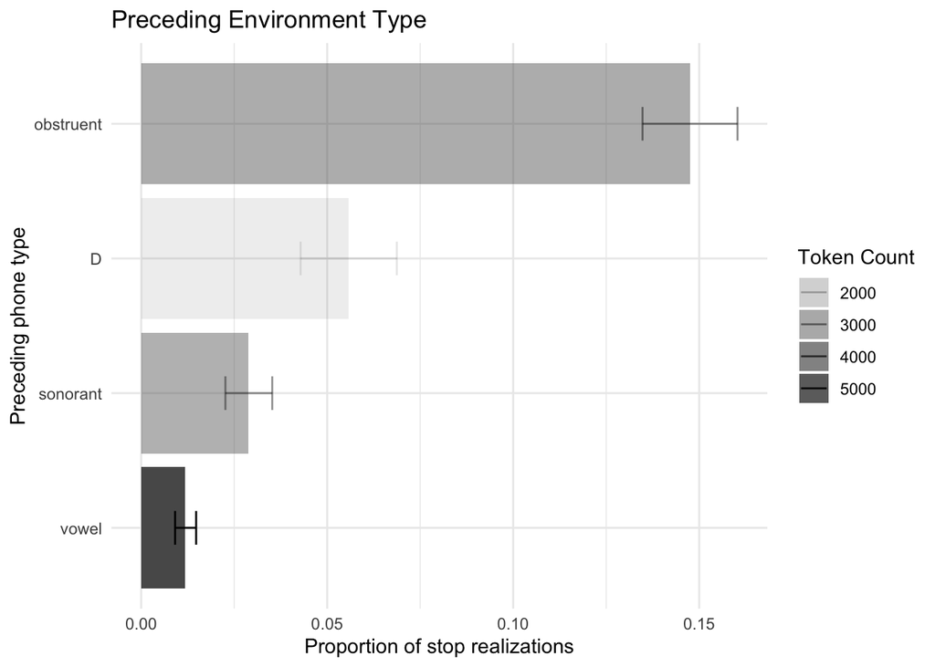

Obstruents are promoting subsequent stops, which can be viewed as an assimilation in that obstruents are the strongest of the classes, and stopping a fricative is a fortition so obstruents are conditioning stops

With D, on the other hand, you don’t get as much of that assimilation because it results in a sequence of two identical segments and it’s difficult to parse a boundary between those so you’re more likely to still produce a fricative

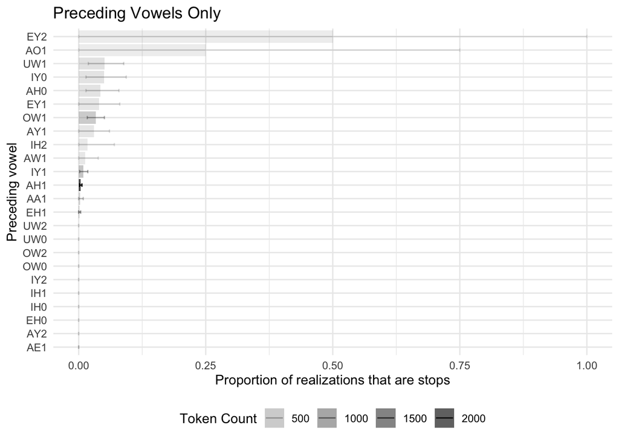

### Word Position

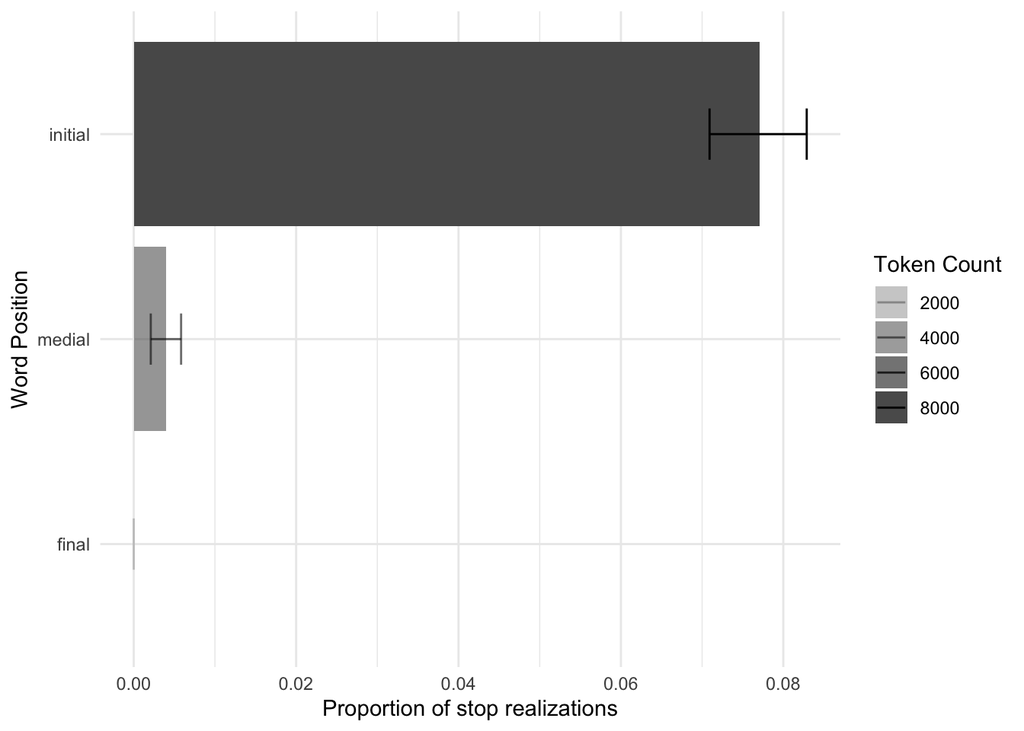

*Word Position Model*

Fixed Effects:

- Word Position (Reference: Initial)

Random Effects:

- Speaker
- Word

```r
pos_lm = lmer(binary_stop ~ word_pos + (1 | speaker.of.DH_data_concat) + (1 | edit_word),
               data = voc_data)
summary(pos_lm)
```

```
## Linear mixed model fit by REML. t-tests use Satterthwaite's method [
## lmerModLmerTest]
## Formula: binary_stop ~ word_pos + (1 | speaker.of.DH_data_concat) + (1 |
##     edit_word)
##    Data: voc_data
##
## REML criterion at convergence: -3024.3
##
## Scaled residuals:
##     Min      1Q  Median      3Q     Max
## -1.7076 -0.3502 -0.1937  0.0266  4.7956
##
## Random effects:
##  Groups                    Name        Variance Std.Dev.
##  speaker.of.DH_data_concat (Intercept) 0.003374 0.05809
##  edit_word                 (Intercept) 0.000181 0.01345
##  Residual                              0.044517 0.21099
## Number of obs: 12403, groups:  speaker.of.DH_data_concat, 189; edit_word, 31
##
## Fixed effects:
##                   Estimate Std. Error         df t value Pr(>|t|)
## (Intercept)        0.02164    0.10712 9987.53119   0.202    0.840
## word_posinitial    0.05174    0.10713 9642.16226   0.483    0.629
## word_posmedial    -0.01579    0.10716 9649.73305  -0.147    0.883
##
## Correlation of Fixed Effects:
##             (Intr) wrd_psn
## word_posntl -0.998
## word_posmdl -0.998  0.998
```

*Frequency Model*

Fixed Effects:

- Word Frequency (Lg10WF)

Random Effects:

- Speaker
- Word

```r
frq_lm = lmer(binary_stop ~ Lg10WF + (1 | speaker.of.DH_data_concat) + (1 | edit_word), data = voc_data)
summary(frq_lm)
```

```
## Linear mixed model fit by REML. t-tests use Satterthwaite's method [
## lmerModLmerTest]
## Formula: binary_stop ~ Lg10WF + (1 | speaker.of.DH_data_concat) + (1 |
##     edit_word)
##    Data: voc_data
##
## REML criterion at convergence: -2997.6
##
## Scaled residuals:
##     Min      1Q  Median      3Q     Max
## -1.7190 -0.3500 -0.1868  0.0200  4.7863
##
## Random effects:
##  Groups                    Name        Variance  Std.Dev.
##  speaker.of.DH_data_concat (Intercept) 0.0033797 0.05814
##  edit_word                 (Intercept) 0.0007295 0.02701
##  Residual                              0.0445248 0.21101
## Number of obs: 12403, groups:  speaker.of.DH_data_concat, 189; edit_word, 31
##
## Fixed effects:
##             Estimate Std. Error       df t value Pr(>|t|)
## (Intercept) -0.09871    0.03403 33.55768  -2.901 0.006528 **
## Lg10WF       0.03093    0.00745 30.19704   4.152 0.000249 ***
## ---
## Signif. codes:  0 '***' 0.001 '**' 0.01 '*' 0.05 '.' 0.1 ' ' 1
##
## Correlation of Fixed Effects:
##        (Intr)
## Lg10WF -0.978
```

*ANOVA for Part of Speech and Frequency Models*

```
## refitting model(s) with ML (instead of REML)
```

```
## Data: voc_data
## Models:
## frq_lm: binary_stop ~ Lg10WF + (1 | speaker.of.DH_data_concat) + (1 | edit_word)
## pos_lm: binary_stop ~ word_pos + (1 | speaker.of.DH_data_concat) + (1 | edit_word)
##        npar     AIC     BIC logLik deviance  Chisq Df Pr(>Chisq)
## frq_lm    5 -3003.7 -2966.6 1506.8  -3013.7
## pos_lm    6 -3031.7 -2987.1 1521.8  -3043.7 29.976  1  4.374e-08 ***
## ---
## Signif. codes:  0 '***' 0.001 '**' 0.01 '*' 0.05 '.' 0.1 ' ' 1
```

We chose position because it resulted in a better model, frequency and position are colinear

### Examining Colinearity of Word Position and Frequency

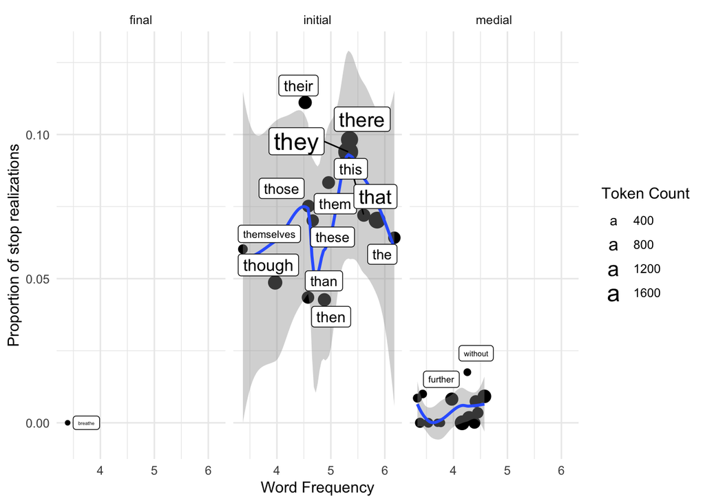

We include word position as the predictor in the model (look at the plot), we note though that there are frequency differences, and when we test frequency separately it’s significant

```r
pos_preceding_lm = lmer(binary_stop ~ word_pos + preceding_cat + (1 | speaker.of.DH_data_concat) + (1 | edit_word),
               data = voc_data)
summary(pos_preceding_lm)
```

```
## Linear mixed model fit by REML. t-tests use Satterthwaite's method [
## lmerModLmerTest]
## Formula:
## binary_stop ~ word_pos + preceding_cat + (1 | speaker.of.DH_data_concat) +
##     (1 | edit_word)
##    Data: voc_data
##
## REML criterion at convergence: -3517
##
## Scaled residuals:
##     Min      1Q  Median      3Q     Max
## -2.0750 -0.4633 -0.1013  0.0831  4.8370
##
## Random effects:
##  Groups                    Name        Variance  Std.Dev.
##  speaker.of.DH_data_concat (Intercept) 3.462e-03 0.058839
##  edit_word                 (Intercept) 8.605e-05 0.009277
##  Residual                              4.270e-02 0.206642
## Number of obs: 12403, groups:  speaker.of.DH_data_concat, 189; edit_word, 31
##
## Fixed effects:
##                          Estimate Std. Error         df t value Pr(>|t|)
## (Intercept)             4.832e-02  1.048e-01  1.124e+04   0.461 0.644890
## word_posinitial         5.611e-03  1.046e-01  1.109e+04   0.054 0.957220
## word_posmedial         -1.992e-02  1.045e-01  1.110e+04  -0.191 0.848842
## preceding_catobstruent  9.225e-02  7.418e-03  2.319e+03  12.437  < 2e-16 ***
## preceding_catsonorant  -2.623e-02  7.588e-03  1.427e+03  -3.456 0.000564 ***
## preceding_catvowel     -2.268e-02  8.219e-03  2.577e+03  -2.759 0.005830 **
## ---
## Signif. codes:  0 '***' 0.001 '**' 0.01 '*' 0.05 '.' 0.1 ' ' 1
##
## Correlation of Fixed Effects:
##             (Intr) wrd_psn wrd_psm prcdng_ctb prcdng_cts
## word_posntl -0.997
## word_posmdl -0.995  0.998
## prcdng_ctbs -0.052  0.001   0.001
## prcdng_ctsn -0.055  0.004   0.001   0.714
## prcdng_ctvw -0.080  0.035   0.004   0.651      0.669
```

We’re filtering out frequency, but not including it in the model because there is no variation in the low-frequency terms

## Social Factors

### Race and Ethnicity

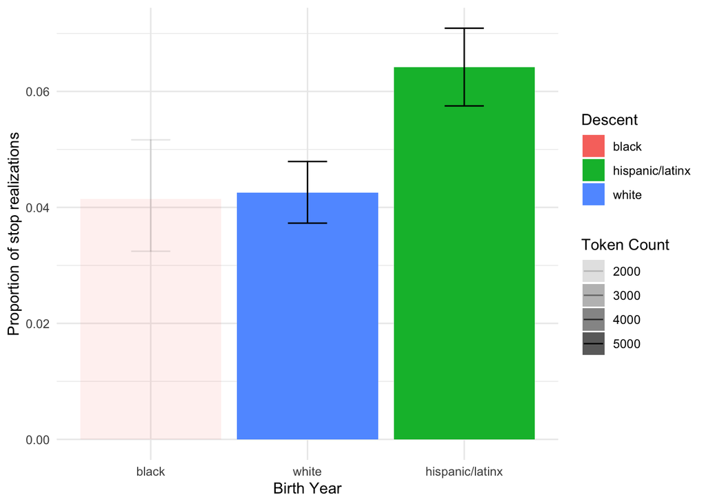

```r
voc_data$descent = factor(voc_data$descent, ordered = FALSE)
voc_data$descent = relevel(voc_data$descent, "hispanic/latinx")

descent_lm = lmer(binary_stop ~ word_pos + preceding_cat + descent + (1 | speaker.of.DH_data_concat) + (1 | edit_word), data = voc_data)

summary(descent_lm)
```

```
## Linear mixed model fit by REML. t-tests use Satterthwaite's method [
## lmerModLmerTest]
## Formula:
## binary_stop ~ word_pos + preceding_cat + descent + (1 | speaker.of.DH_data_concat) +
##     (1 | edit_word)
##    Data: voc_data
##
## REML criterion at convergence: -3507.9
##
## Scaled residuals:
##     Min      1Q  Median      3Q     Max
## -2.0813 -0.4616 -0.0984  0.0819  4.8369
##
## Random effects:
##  Groups                    Name        Variance  Std.Dev.
##  speaker.of.DH_data_concat (Intercept) 3.425e-03 0.058525
##  edit_word                 (Intercept) 8.587e-05 0.009267
##  Residual                              4.270e-02 0.206630
## Number of obs: 12403, groups:  speaker.of.DH_data_concat, 189; edit_word, 31
##
## Fixed effects:
##                          Estimate Std. Error         df t value Pr(>|t|)
## (Intercept)             6.101e-02  1.050e-01  1.128e+04   0.581 0.561200
## word_posinitial         3.744e-03  1.046e-01  1.109e+04   0.036 0.971440
## word_posmedial         -2.193e-02  1.045e-01  1.110e+04  -0.210 0.833817
## preceding_catobstruent  9.204e-02  7.417e-03  2.317e+03  12.409  < 2e-16 ***
## preceding_catsonorant  -2.631e-02  7.587e-03  1.425e+03  -3.467 0.000542 ***
## preceding_catvowel     -2.277e-02  8.218e-03  2.575e+03  -2.770 0.005641 **
## descentblack           -8.441e-03  1.417e-02  2.128e+02  -0.596 0.552038
## descentwhite           -2.244e-02  9.935e-03  1.861e+02  -2.259 0.025073 *
## ---
## Signif. codes:  0 '***' 0.001 '**' 0.01 '*' 0.05 '.' 0.1 ' ' 1
##
## Correlation of Fixed Effects:
##             (Intr) wrd_psn wrd_psm prcdng_ctb prcdng_cts prcdng_ctv dscntb
## word_posntl -0.996
## word_posmdl -0.994  0.998
## prcdng_ctbs -0.052  0.001   0.001
## prcdng_ctsn -0.055  0.004   0.001   0.714
## prcdng_ctvw -0.080  0.035   0.004   0.651      0.669
## descentblck -0.034  0.000   0.000   0.005      0.002     -0.001
## descentwhit -0.055  0.008   0.008   0.012      0.005      0.004      0.384
```

Evidence that Hispanic speakers are stopping more than white speakers, but no evidence that they are doing so more than Black speakers, likely as a result of low token counts and a relative lack of variation within the Black speakers

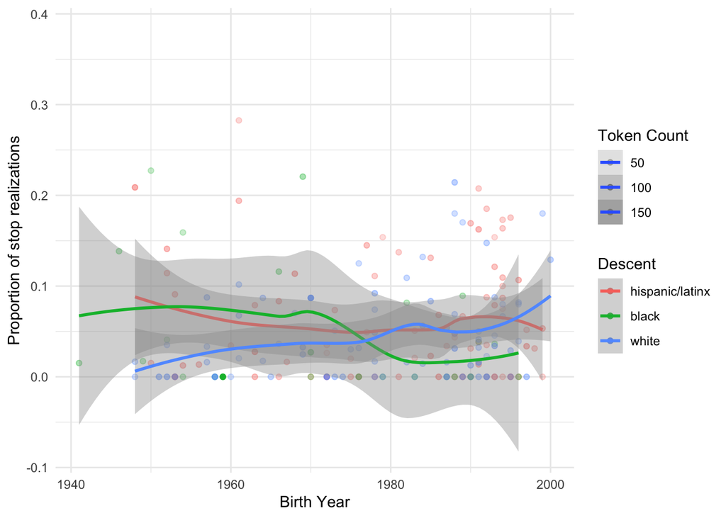

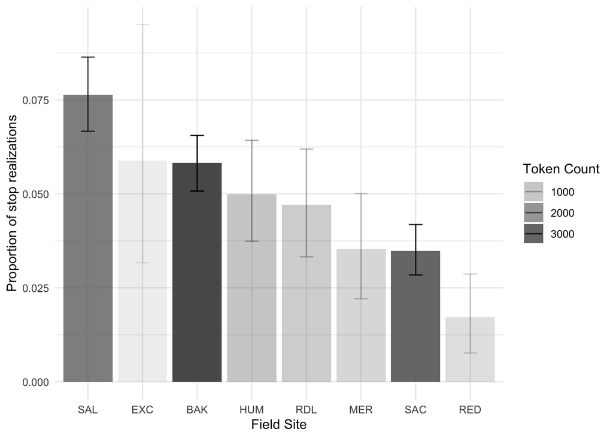

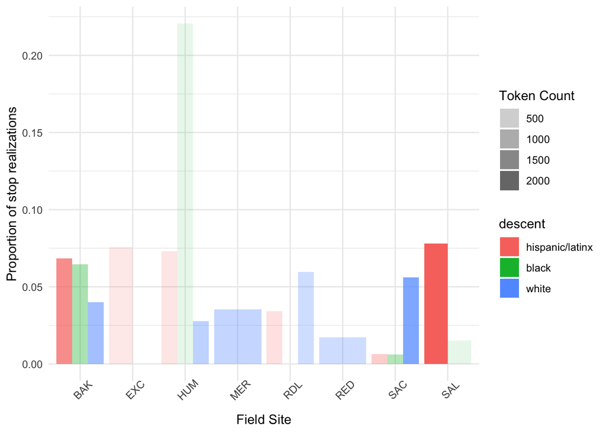

Bakersfield is the only community in which we see significant amounts of stopping for all ethnic groups and we don’t want tot interpret the very high rate of stopping in HUM because it’s a low token count. We can be reasonably confident that the rate of stopping in Hispanic speakers in SAL because it’s the intersection of site and race that is best represented.

- Not going to interact race with field site, and not draw any conclusions about field site at all. No reliable effect of site that goes beyond the effects of descent

### Gender

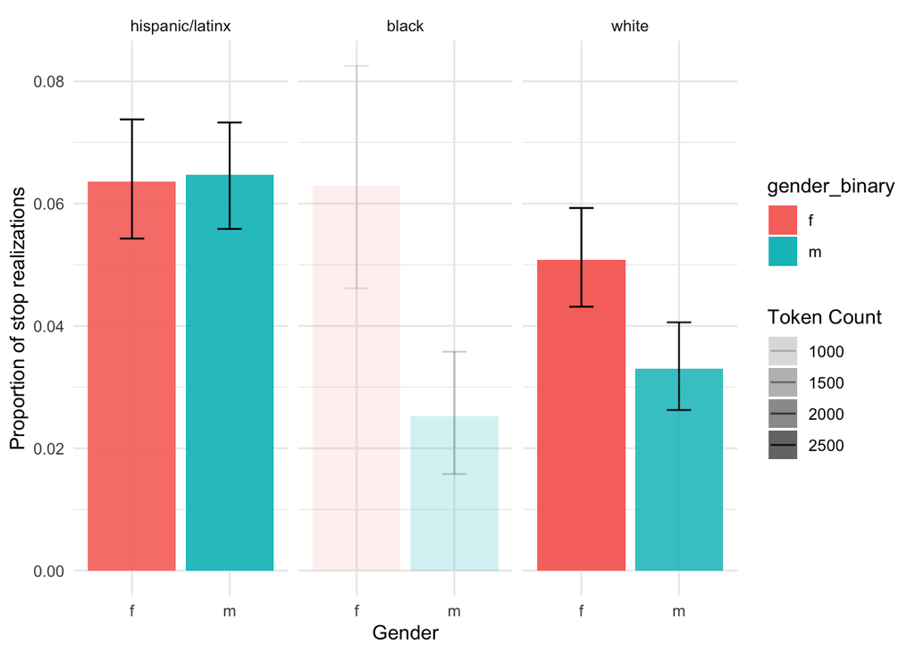

No effect of gender for Hispanic population, but definitely for white speakers and probably (?) for Black speakers

*Model*

```r
gender_lm = lmer(binary_stop ~ word_pos + preceding_cat + descent*gender_binary + (1 | speaker.of.DH_data_concat) + (1 | edit_word), data = voc_data)

summary(gender_lm)
```

```
## Linear mixed model fit by REML. t-tests use Satterthwaite's method [
## lmerModLmerTest]
## Formula: binary_stop ~ word_pos + preceding_cat + descent * gender_binary +
##     (1 | speaker.of.DH_data_concat) + (1 | edit_word)
##    Data: voc_data
##
## REML criterion at convergence: -3493.4
##
## Scaled residuals:
##     Min      1Q  Median      3Q     Max
## -2.0833 -0.4633 -0.0969  0.0832  4.8478
##
## Random effects:
##  Groups                    Name        Variance  Std.Dev.
##  speaker.of.DH_data_concat (Intercept) 3.421e-03 0.058487
##  edit_word                 (Intercept) 8.579e-05 0.009262
##  Residual                              4.269e-02 0.206619
## Number of obs: 12403, groups:  speaker.of.DH_data_concat, 189; edit_word, 31
##
## Fixed effects:
##                               Estimate Std. Error         df t value Pr(>|t|)
## (Intercept)                  6.322e-02  1.052e-01  1.133e+04   0.601 0.547994
## word_posinitial              3.702e-03  1.046e-01  1.109e+04   0.035 0.971762
## word_posmedial              -2.186e-02  1.045e-01  1.110e+04  -0.209 0.834323
## preceding_catobstruent       9.216e-02  7.417e-03  2.316e+03  12.425  < 2e-16
## preceding_catsonorant       -2.628e-02  7.587e-03  1.424e+03  -3.463 0.000549
## preceding_catvowel          -2.280e-02  8.218e-03  2.574e+03  -2.774 0.005571
## descentblack                 1.113e-02  1.980e-02  2.438e+02   0.562 0.574609
## descentwhite                -1.628e-02  1.379e-02  1.855e+02  -1.181 0.239214
## gender_binarym              -4.442e-03  1.401e-02  1.786e+02  -0.317 0.751572
## descentblack:gender_binarym -3.926e-02  2.837e-02  2.050e+02  -1.384 0.167892
## descentwhite:gender_binarym -1.239e-02  1.991e-02  1.812e+02  -0.623 0.534343
##
## (Intercept)
## word_posinitial
## word_posmedial
## preceding_catobstruent      ***
## preceding_catsonorant       ***
## preceding_catvowel          **
## descentblack
```

[output cut: 15 more lines]

```
## descentwhit -0.074  0.005   0.006   0.011      0.005      0.004      0.424
## gendr_bnrym -0.067  0.000   0.000  -0.005     -0.004      0.000      0.354
## dscntblck:_  0.033  0.000   0.000   0.000      0.004      0.003     -0.698
## dscntwht:g_  0.047  0.000   0.000  -0.003     -0.002     -0.001     -0.293
##             dscntw gndr_b dscntb:_
## word_posntl
## word_posmdl
## prcdng_ctbs
## prcdng_ctsn
## prcdng_ctvw
## descentblck
## descentwhit
## gendr_bnrym  0.509
## dscntblck:_ -0.296 -0.494
## dscntwht:g_ -0.692 -0.704  0.378
```

We don’t see an interaction between race and gender

### Education

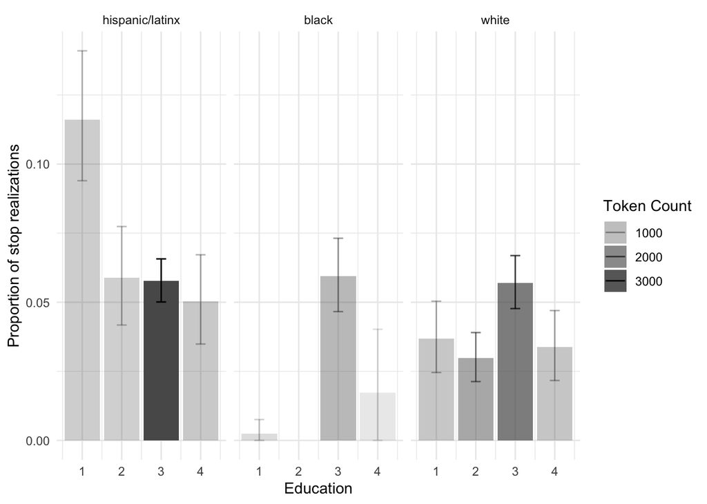

*Model*

```r
voc_hispanic <- voc_data %>%
  filter(descent == "hispanic/latinx") %>%
  filter(education_cont %in% c(1,3))

educ_hisp_lm = lmer(binary_stop ~ word_pos + preceding_cat + education_cont + (1 | speaker.of.DH_data_concat) + (1 | edit_word), data = voc_hispanic)
```

```
## boundary (singular) fit: see help('isSingular')
```

```r
summary(educ_hisp_lm)
```

```
## Linear mixed model fit by REML. t-tests use Satterthwaite's method [
## lmerModLmerTest]
## Formula: binary_stop ~ word_pos + preceding_cat + education_cont + (1 |
##     speaker.of.DH_data_concat) + (1 | edit_word)
##    Data: voc_hispanic
##
## REML criterion at convergence: -167.7
##
## Scaled residuals:
##     Min      1Q  Median      3Q     Max
## -1.4182 -0.4917 -0.1202  0.0976  4.2883
##
## Random effects:
##  Groups                    Name        Variance Std.Dev.
##  speaker.of.DH_data_concat (Intercept) 0.003137 0.05601
##  edit_word                 (Intercept) 0.000000 0.00000
##  Residual                              0.054279 0.23298
## Number of obs: 3954, groups:  speaker.of.DH_data_concat, 61; edit_word, 30
##
## Fixed effects:
##                          Estimate Std. Error         df t value Pr(>|t|)
## (Intercept)               0.13545    0.03161   80.46229   4.285 5.02e-05 ***
## word_posmedial           -0.02923    0.01200 3928.10783  -2.435   0.0149 *
## preceding_catobstruent    0.12465    0.01478 3915.02736   8.436  < 2e-16 ***
## preceding_catsonorant    -0.03181    0.01504 3914.88482  -2.115   0.0345 *
## preceding_catvowel       -0.03894    0.01659 3915.09862  -2.347   0.0190 *
## education_cont           -0.02451    0.01059   57.92026  -2.315   0.0242 *
## ---
## Signif. codes:  0 '***' 0.001 '**' 0.01 '*' 0.05 '.' 0.1 ' ' 1
##
## Correlation of Fixed Effects:
##             (Intr) wrd_ps prcdng_ctb prcdng_cts prcdng_ctv
## word_posmdl  0.008
## prcdng_ctbs -0.348 -0.002
## prcdng_ctsn -0.348 -0.061  0.728
## prcdng_ctvw -0.316 -0.544  0.660      0.681
## educatn_cnt -0.887 -0.008  0.002      0.009      0.009
## optimizer (nloptwrap) convergence code: 0 (OK)
## boundary (singular) fit: see help('isSingular')
```

The group with the highest rate of stopping NUMERICALLY is Hispanic HS, significantly different from college students but we don’t have enough data to say if they are significantly different from some college/AS speakers. This was achieved by a by-hand ordinal analysis.

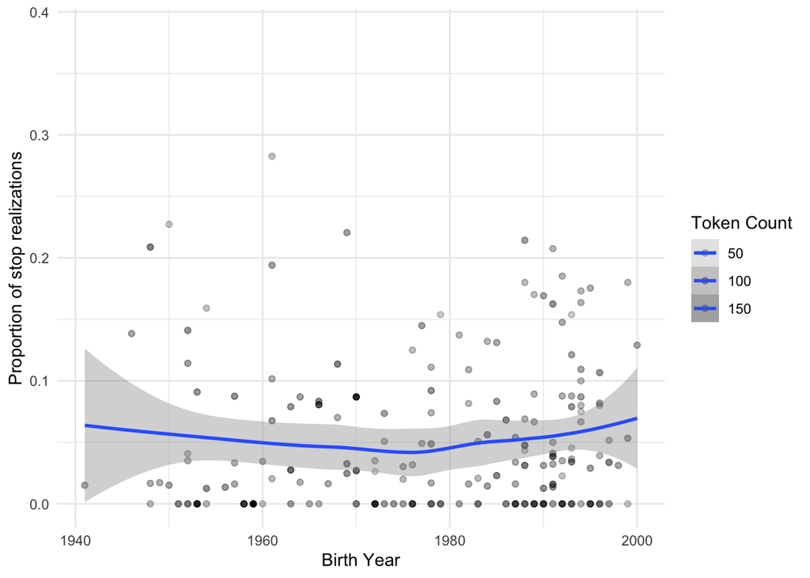

# Notes

WE ARE KEEPING WITHOUT!!

Add error bars to bar plots Figure out pivot_longer because wtf besties!!

ToDo:

- Bilingualism:Site:Gender:Birthyear:Education
- Only for Hispanic
- SAL and BAK only